# Simple Linear Regression

```r
# Load your libraries
library(pander)
library(car)
library(DT)
library(mosaic)
library(tidyverse)

# Load your data after saving a csv file in your Data folder.
# You can use either
My_data <- read.csv("../../Data/LinearRegression.csv", header=TRUE)
# or
#   library(readr)
#   someName <- read_csv("../Data/YourDataFileName.csv")

# Don't forget to run "Session -> Set Working Directory -> To Source file location"
```

## Background

The following dataset labelled MY_data is a personal data set that i got from my friends here at BYU Idaho mostly my roomates. I asked them how much they study and their grade for a certain class.

## Introduction

Good Grades are important in school, So how do we get these good grades ? A good analysis thats seems to be reliable is checking if the amount of effort put into studying has any impact on a persons grade in a particular class. But at the same time they say all work and no play makes Jack a dull boy so maybe over studying may have dminishing returns.

## Hypothesis Test

Null hypothesis says that there is no relationship between study hours and the grade that a person got.

$$H_0: \beta_1 = 0$$

$$\alpha = 0.05$$

I am using an alpha level of 0.05

The Ha Hypothesis is saying that X and Y are related so a persons grade is related to the hours they put into their study or their grade is predicated on the amount of time in Hours spent studying.

$$H_a: \beta_1 \neq 0$$

$$\text{Grade} = 58.75 + 4.25 \times \text{(Study Time in hours)}$$

### Explanation of the Equation.

From the above Hypothesis we are assuming that for every additional hour of study, a persons grade will increse by 4.25 points.

## Regression Model

```r
regret.lm <- lm(Grade ~ Hours.Studied, data=My_data)
pander(summary(regret.lm))
```

|  | Estimate | Std. Error | t value | Pr(>\|t\|) |
| --- | --- | --- | --- | --- |
| **(Intercept)** | 58.75 | 4.123 | 14.25 | 1.994e-06 |
| **Hours.Studied** | 4.25 | 0.5594 | 7.598 | 0.0001265 |

Fitting linear model: Grade ~ Hours.Studied

| Observations | Residual Std. Error | $R^2$ | Adjusted $R^2$ |
| --- | --- | --- | --- |
| 9 | 4.862 | 0.8918 | 0.8764 |

$$\underbrace{\hat{Y}_i}_\text{Ave.Grade.} = 58.75 + 4.25
\underbrace{X_i}_\text{Study Time in Hours }$$

## Graphical Summary

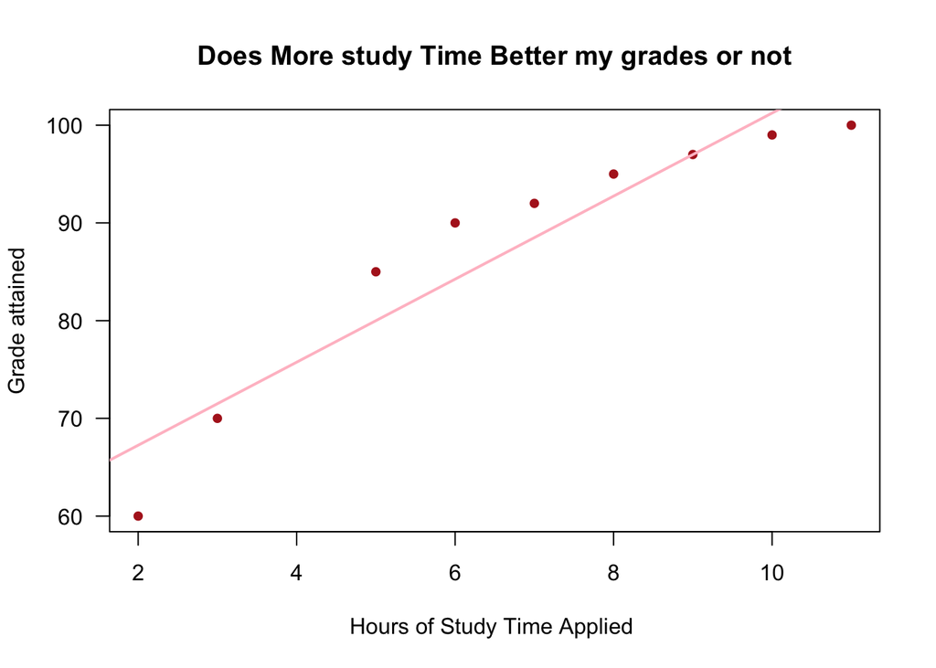

```r
plot(Grade ~ Hours.Studied, data=My_data, pch=20, col="firebrick", cex=1.2, las=1,
     xlab="Hours of Study Time Applied ", ylab="Grade attained",
     main="Does More study Time Better my grades or not")

abline(regret.lm, lwd=2, col="pink")
```

## Explanation

The above plot shows the hours of study time applied and the grade that a person gets in a class, from this plot we see that the more hours applied to studying the better the grade.

## Numerical summary.

```r
favstats( My_data$Hours.Studied) |> pander()
```

| min | Q1 | median | Q3 | max | mean | sd | n | missing |
| --- | --- | --- | --- | --- | --- | --- | --- | --- |
| 2 | 5 | 7 | 9 | 11 | 6.778 | 3.073 | 9 | 0 |

```r
favstats( My_data$Grade)|>pander()
```

| min | Q1 | median | Q3 | max | mean | sd | n | missing |
| --- | --- | --- | --- | --- | --- | --- | --- | --- |
| 60 | 85 | 92 | 97 | 100 | 87.56 | 13.83 | 9 | 0 |

## Explanation

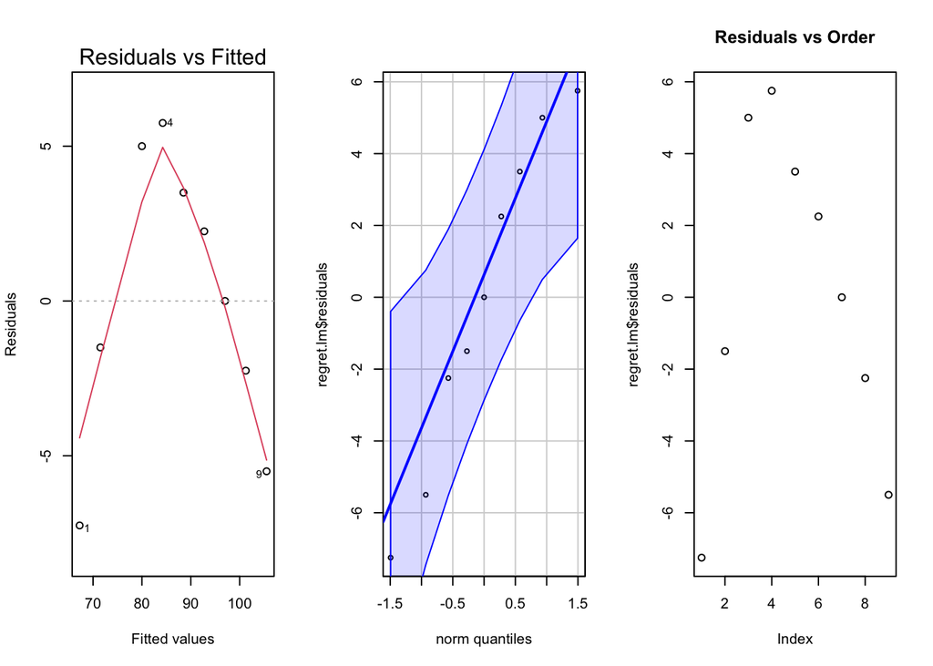

```r
par(mfrow=c(1,3))
plot(regret.lm, which=1)
qqPlot(regret.lm$residuals, id=FALSE)
plot(regret.lm$residuals, main="Residuals vs Order")
```

## Assumption Plot Interpretation.

There is a linear relationship problem with the data because the residual vs fitted have a sharp downward curve. On the residual vs order there is a sharp curve too. The Constant variance is not too much of an issue even though there is curvature. The other plot is the normality plot and it looks good because the data points are on the line. The third plot is for independence and there seems to be a problem because the data does not seem independent because theres a pattern.

## Conclusion

The P value was significant low so the more a person studies, their grade increases as well. But one of the most important assumptions is that there must be a linear relationship between the x and y variables. since this important assumption is not met, then we cant trust the data.